# AF 603 – Fish population dynamics and stock assessment

Course Introduction

Nyamisi Peter

2026-11-04

## Course Introduction

### Learning Objectives

- Understand core stock assessment principles
- Identify different data types used in assessments
- Apply concepts to real Tanzania fisheries data
- Build foundation for advanced methods

### Why This is Important?

- Essential for evidence-based management
- Reinforces foundational knowledge
- Prepares for data-limited methods
- Supports sustainable fisheries

## Stock Assessment Fundamentals & Concepts

- Stock assessment is the process of evaluating the status of a fish population using available data and scientific methods to inform management decisions.
- Stock assessment is the **scientific process** of estimating the status and productivity of fish populations to inform management decisions.
- Is examination of development of fish stock using mathematical and statistical models to make quantitative predictions in order to address fisheries management issues.
- **Stock assessment** is the process of collecting and analyzing demographic information about fish populations in order to describe the conditions or status of fish stock
- Stock assessment describe a range of life history characteristics for a given species
  - It includes age, growth, natural mortality, sexual maturity and reproduction, stock boundaries, diet preferences, habitat characteristics, species interactions, and environmental factors that may affect the species
- Assessment also include descriptions of the fishery for a species, using information from both scientists and fishermen

## Aim of stock assessment

- Assessment of the current state of stock
- Assessment of the past stock situation
- Predictions to the future stock based on management choices
- An estimation of the rate at which it is being removed due to harvesting etc.

## Key questions it answers

- How many fish are in the stock?
- Are we fishing sustainably?
- What catch level can we maintain indefinitely?
- Is the stock recovering or declining?
- Why stock assessment matters for management
- Assessment approaches (data-rich vs. data-limited)
- Success factors in assessment

## Key Components of Stock Assessment

- **Population Dynamics**: How fish populations change over time
- **Catch Data**: What we remove from the stock
- **Biological Data**: Growth, reproduction, mortality
- **Environmental Context**: Habitat and external factors

## The Assessment Cycle

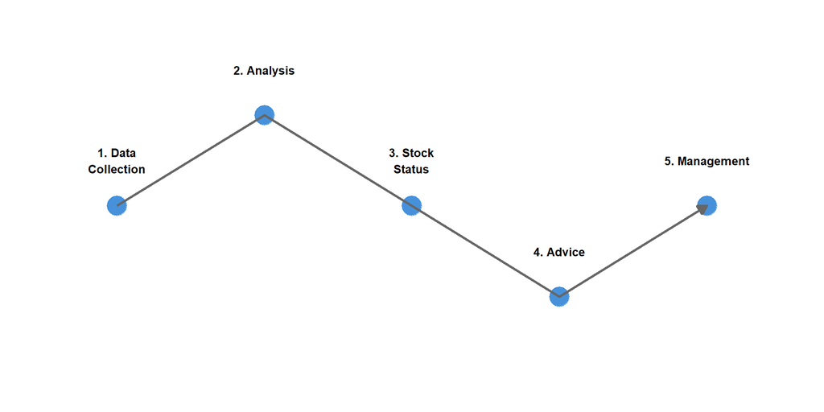

## Key Biological Parameters

- These includes:
- **Growth:** von Bertalanffy growth curves, length-weight relationships
- **Mortality:** Natural mortality, fishing mortality, total mortality
- **Recruitment:** Recruitment variations, stock-recruitment relationships
- **Maturity:** Age/size at maturity, fecundity (egg production)

## Introduction to population dynamics

**What is population?**

- A population is a group of individuals of the same species that live together in a particular area
- A fish population is a group of fish of the same species that live in a particular area.

## Introduction to population dynamics

- **Fish population dynamics** describes the ways in which a given fishery population grows and shrinks over time, as controlled by **birth**, **death**, and **migration**
- It is a basis for understanding changes of fishery patterns and issues such as **habitat destruction**, **predation** and **optimal harvesting rates**
- The population dynamics of fisheries is used by fisheries scientists to determine sustainable yields.

## Introduction to population dynamics

- Population dynamics is a branch of life science dealing with the short and long-term changes in the size and age composition of populations, and the biological and environmental processes influencing those changes.
- It deals with the way populations are affected by *birth* and *death rates*, and by *immigration and emmigration*.

## Definition of key terms

- **Fish Catch** is the total number or weight of fish captured from an area over a period of time.
- This includes fish that are caught but released or discarded instead of being landed.
- **Carrying Capacity** is amount of fish that a specific habitat can support.
- **Bycatch** is the harvest of fish or animals other than the species for which the fishing gear was intended

## Definition of key terms…

- **Catch Per Unit Effort (CPUE)** is the quantity of fish caught (in number or in weight) with one standard unit of fishing effort.
- Effort can be number of fishing gear or vessel, length of time used during fishing, number of fishermen etc.
- e.g. number of fish taken per 1000 hooks per day or weight of fish taken per hour of trawling.
- CPUE is often considered as an index of fish biomass (or abundance).
- CPUE is also referred to as **catch rate**

## Definition of key terms…

- **Effort** is the amount of time and fishing power used to harvest fish.
- Fishing power includes gear size, boat size, and horsepower.
- **Fish Density** is the number of fish per unit area.
- **Spawning** the number of eggs and sperm released into water by fish.
- **Spawning rate** is the number of eggs and sperm released per unit time

## Definition of key terms…

- **Cohort** is a group of fish spawned during a given period, usually within a year
- **Recruitment** the number of new young fish that enter a population in a given year.
- **Morphometrics** these are measurements which characterize the form, shape and appearance of a fish.
- Difference in morphometrics, such as colouration, can be used to distinguish different stocks of the same species.

## Definition of key terms…

- **Maximum sustainable yield (MSY)** is theoretical harvest of a fish species that can be taken over an indefinite period.
- **MSY** theoretically aims to maintain the population size at the point of maximum growth rate by harvesting the individuals that would normally be added to the population.
- **MSY** has been widely criticized and has led to the collapse of many fisheries, as it ignores size, age, reproductive capacity, and fishing effort.

## Definition of key terms…

- **Fish mortality** is a parameter that account for the loss of fish in a fish stock through death.
- The mortality can be divided into two types;
  - **Natural mortality** – the removal of fish from stock due to causes not associated with fishing.
  - Such causes can include disease, competition, cannibalism, old age, predation, pollution or any other natural factor that causes the death of fish.
  - In fisheries models natural mortality is denoted by (M)

## Definition of key terms…

- **Fishing mortality** – the removal of fish from stock due to fishing activities using any fishing gear.
- It is denoted by (F) in fisheries models.
- **Mortality rate** or **death rate** is a measure of the number of deaths in a particular population per unit time.
- Mortality rate is the rate at which fish die, typically shown as a percentage.
- **Survival rate** is a measure of number of alive fishes in a particular population per unit time

## Definition of key terms…

- If 1,000 fish are alive at the beginning of the year and 200 fish die, leaving 800 at the end of the year

  $$Mortality~rate = \frac{Number~of~fishes~that~died}{Initial~number~of~fishes}*100\%$$

  $$Mortality~rate = \frac{200}{1000}*100\%$$
  $$Annual~mortality~rate=20\%$$

## Definition of key terms…

$$Survival~rate=\frac{Number~of~alive~fishes}{Initial~number~of~fishes}*100\%$$

$$Survival~rate=\frac{800}{1000}*100\%$$

$$Annual~survival~rate=80\%$$

## Definition of key terms…

- **Fecundity** is the number of eggs or offsprings produced by fish during the spawning season.
- The number of eggs produced by a fish differs in different species, and depends on the size and age of the fish.
- It is a measure of the reproductive capacity of a female fish

## Definition of key terms…

- **Gonadosomatic index (GSI)** is a metric that represents the relative weight of the gonad to the fish weight.
- GSI has been widely used to evaluate reproduction timing (Lowerre-Barbieri et al., 2011)
- Changes in GSI are mostly determined by variations in yolk concentration during different oocyte stages
- Therefore, it provides information about maturation and seasonal patterns in gonad development

## Definition of key terms…

$$Gonadosomatic~index~(GSI)=\frac{Weight~of~gonads}{Weight~fish}*100\%$$

- GSI of the fish increases with maturation of the fish;
  - It is **maximum** during the **peak period of maturity** and
  - It **decline** abruptly **after spawning**